# Unassessed Coursework

Hrishi Singh

05/03/2021

## Summary

In this report we investigate the potential relationship between the number of cigarettes sold and the number of deaths from various forms of cancer.

## Introduction

Cigarettes are known to contain many cancer causing substances. Therefore, by comparing cigarettes sold and the number of cancer deaths in 43 US states we can determine whether a correlation exists or not as we can assume areas where more cigarettes are sold also have more people who smoke cigarettes.

## Methods

This report uses exploratory methods like plotting histograms, botplots and scatter graphs.

## Results

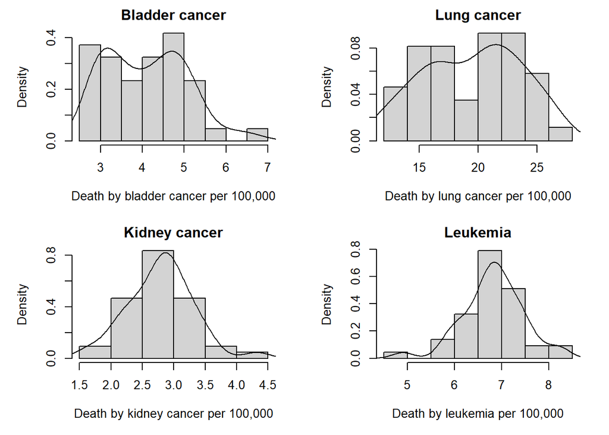

Firstly deaths from bladder cancer appear to demonstrate a bimodal distribution and be positively skewed. Deaths from lung cancer also appear to show a bimodal distribtuion but seems to be more symmetrical. Deaths from kidney cancer and leukemia both have a unimodal distribution and seem symmetrical. However, leukemia is very slightly negatively skewed whereas kidney cancer appears more symmetrical. Both closely remesemble the normal distribution.

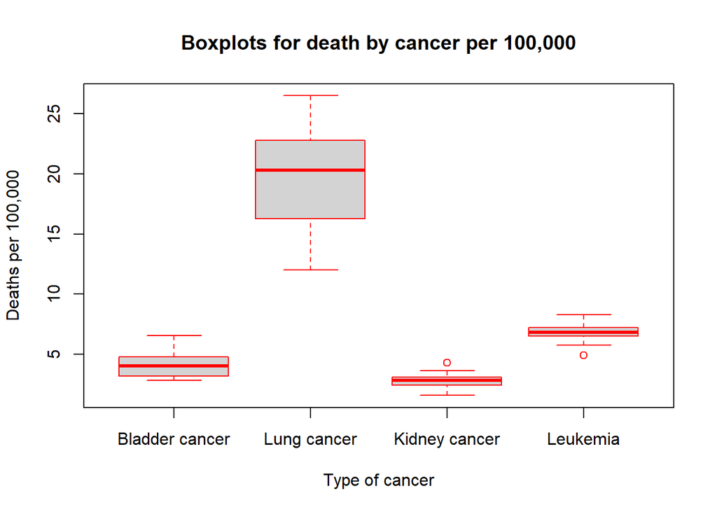

Deaths from lung cancer per 100,000 have both the greatest maximum value (26.48) and the greatest minimum value (12.01) out of all deaths from any type of cancer. Furthermore, the mean of deaths from lung cancer is 19.4760465 which is the greatest. Collectively this indicates that lung cancer causes the most deaths out of the 4 types of cancer. Moreover the interquartile range is 6.475 and the standard deviation is 4.1096473 which are both the largest interquartile range and standard deviation respectively suggesting the data points are the furthest from the mean out of the 4 types of cancer.

Deaths from bladder cancer per 100,000 have a mean of 4.0867442 and standard deviation of 0.948665.

Deaths from kidney cancer per 100,000 have a mean of 2.7867442. Deaths from kidney cancer have the smallest mean and smallest largest value 4.32. This indicates kidney cancer causes the least death per 100,000 out of the 4 types of cancer. The standard deviation is 0.5226067, which is the smallest indicating the data points are the most closely clustered around the mean. The data point of 4.32 deaths per 100,000 appears to be an outlier.

Deaths from leukemia per 100,000 have a mean of 6.8239535 and standard deviation of 0.6446303. The data point of 4.90 deaths per 100,000 appears to be an outlier.

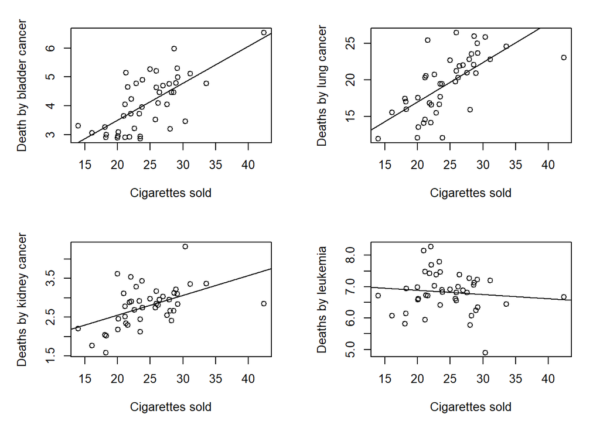

For lung cancer, bladder cancer and kidney cancer, as the number of cigarettes sold increase, the number of deaths also increase illustrating their positive correlation. In particular, lung cancer has the strongest correlation as the steepness of the line of best fit is the greatest - the deaths from lung cancer increase more rapidly as the number of cigarettes sold than deaths from bladder cancer or kidney cancer. For leukemia there is a weak negative correlation. This suggest there is no evidence suggesting deaths increase as cigarettes sold increase. a weak negative correlation. On the contrary, there could be an argument made from the graph that deaths from leukemia decrease as the number cigarettes sold increase.

## Conclusion

We conclude that as the number of cigarettes sold increase, the number of deaths from lung cancer, kidney cancer and bladder cancer increase but deaths from lung cancer increase the most.

This study has several limitation. Firstly we only have data about the number of cigarettes sold. This doesn’t give a concrete link between the affects of smoking cigarettes and cancer as many of the cigarettes may have never been smoked. Moreover we concluded that lung cancer causes the most death out of the 4 types of cancer. This could be making the claim that smoking more cigarettes causes more deaths from lung cancer than any other cancer seem more truthfully than it actually is. Where in actual fact the reason more deaths are occurring is because lung cancer causes more death than other types of cancer.

```r
# read in the data
dat <- read.csv("UScancer.csv", header=TRUE)

par(mfrow = c(2,2),mar = c(5,5,2,2))
hist(dat$BLAD, main = "Bladder cancer",
     xlab = "Death by bladder cancer per 100,000",
     freq = FALSE)
lines(density(dat$BLAD,na.rm=T),lwd = 1 )

hist(dat$LUNG, main = "Lung cancer",
     xlab = "Death by lung cancer per 100,000",
     freq = FALSE)
lines(density(dat$LUNG,na.rm=T),lwd =1)

hist(dat$KID,main = "Kidney cancer",
     xlab = "Death by kidney cancer per 100,000",
     freq = F)
lines(density(dat$KID,na.rm = T),lwd = 1)

hist(dat$LEUK,main = "Leukemia",
     xlab = "Death by leukemia per 100,000",
     freq = F)
lines(density(dat$LEUK,na.rm = T),lwd = 1)
sd_blad <- sd(dat$BLAD)
mean_blad <- mean(dat$BLAD)
sd_lung <- sd(dat$LUNG)
mean_lung <- mean(dat$LUNG)
sd_kid <- sd(dat$KID)
mean_kid <- mean(dat$KID)
sd_leuk <- sd(dat$LEUK)
mean_leuk <- mean(dat$LEUK)


boxplot(dat$BLAD,dat$LUNG,dat$KID,dat$LEUK,
        main = "Boxplots for death by cancer per 100,000",
        names = c("Bladder cancer","Lung cancer","Kidney cancer","Leukemia"),
        border = "red",
        notch = FALSE,
        xlab = "Type of cancer",
        ylab = "Deaths per 100,000")
max_lung <- max(dat$LUNG)
min_lung <- min(dat$LUNG)
iqr_lung <- IQR(dat$LUNG)
max_kid <- max(dat$KID)

x <- dat$CIG
par(mfrow = c(2,2),mar = c(5,5,2,2)) #bottom,left,top,right
plot(x,dat$BLAD,
     xlab = "Cigarettes sold",
     ylab = "Death by bladder cancer",
     )
abline(lm(dat$BLAD~dat$CIG))
plot(x,dat$LUNG,
     xlab = "Cigarettes sold",
     ylab = "Deaths by lung cancer" )
abline(lm(dat$LUNG~dat$CIG))
plot(x,dat$KID,
     xlab = "Cigarettes sold",
     ylab = "Deaths by kidney cancer")
abline(lm(dat$KID~dat$CIG))
plot(x,dat$LEUK,
     xlab = "Cigarettes sold",
     ylab = "Deaths by leukemia")
abline(lm(dat$LEUK~dat$CIG))
```